# Untitled

Roman Olenev

2023-11-08

```r
dataset <- read.csv("C:/Users/roman/Downloads/possum.csv")
head(dataset)
```

```
##   case site Pop sex age hdlngth skullw totlngth taill footlgth earconch  eye
## 1    1    1 Vic   m   8    94.1   60.4     89.0  36.0     74.5     54.5 15.2
## 2    2    1 Vic   f   6    92.5   57.6     91.5  36.5     72.5     51.2 16.0
## 3    3    1 Vic   f   6    94.0   60.0     95.5  39.0     75.4     51.9 15.5
## 4    4    1 Vic   f   6    93.2   57.1     92.0  38.0     76.1     52.2 15.2
## 5    5    1 Vic   f   2    91.5   56.3     85.5  36.0     71.0     53.2 15.1
## 6    6    1 Vic   f   1    93.1   54.8     90.5  35.5     73.2     53.6 14.2
##   chest belly
## 1  28.0    36
## 2  28.5    33
## 3  30.0    34
## 4  28.0    34
## 5  28.5    33
## 6  30.0    32
```

```r
dataset <- dataset %>% select(-case)
```

site - место, в котором поймали опоссума

Pop - популяция: Vic - Victoria, other - New South Wales or Queensland

sex - пол

age - возраст

hdlngth - длина головы в мм

skullw - ширина черепа в мм

totlngth - полная длина в см

taill - длина хвоста

footlgth - длина лапы

earconch - длина ушной раковины

eye - длина правого глаза

chest - обхват груди в см

belly - обхват живота в см

Удаляем пропуски в данных

```r
na_num <- sapply(dataset, function(y) sum(length(which(is.na(y)))))
na_num
```

```
##     site      Pop      sex      age  hdlngth   skullw totlngth    taill
##        0        0        0        2        0        0        0        0
## footlgth earconch      eye    chest    belly
##        1        0        0        0        0
```

```r
dataset1 <- drop_na(dataset)
sum(is.na(dataset1))
```

```
## [1] 0
```

Видна неоднородность

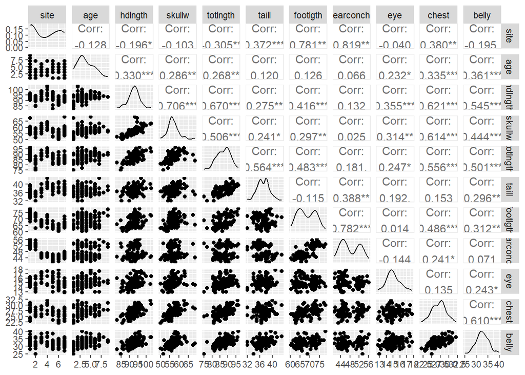

```r
dataset2 <- dataset1 %>% select(-c(Pop,sex))
ggpairs(dataset2)
```

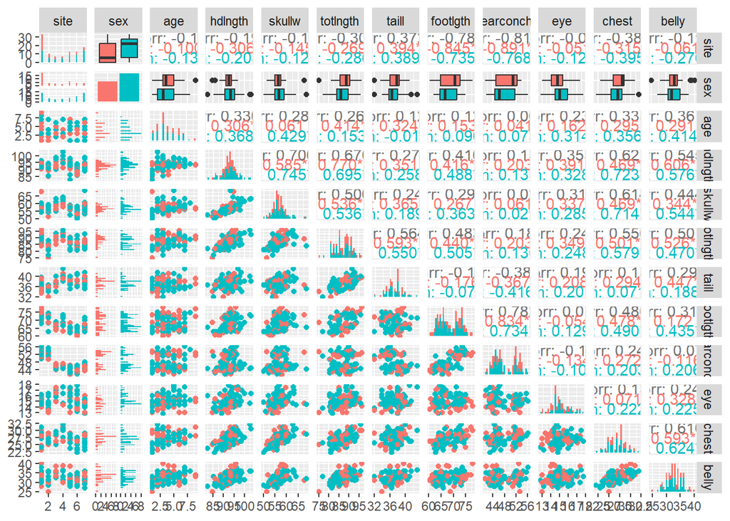

```r
dataset2 <- dataset1 %>% select(-Pop)
ggpairs(dataset2, aes(color=sex), diag=list(continuous="barDiag"))
```

Неоднородность по признаку Pop

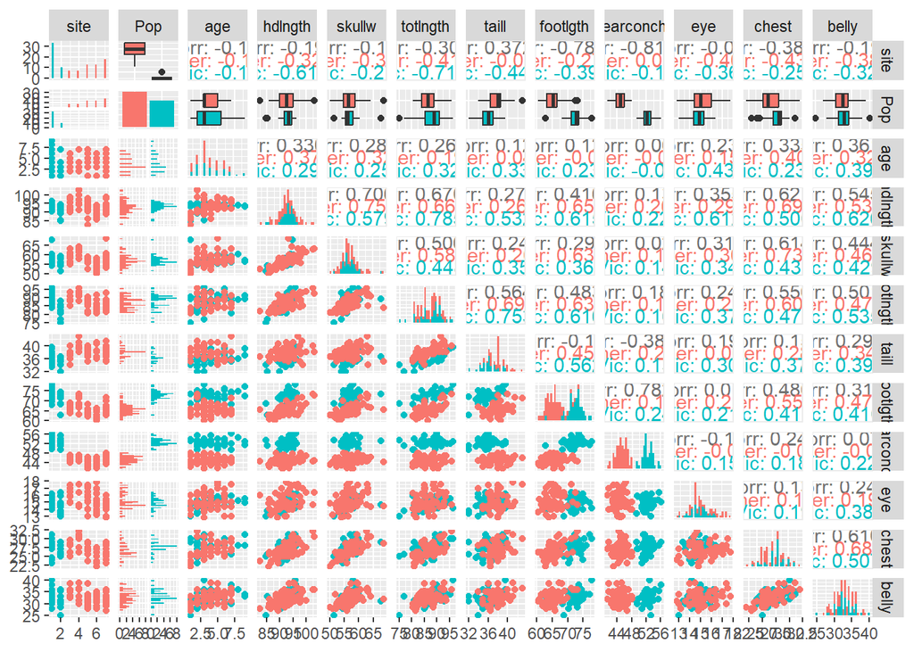

```r
dataset2 <- dataset1 %>% select(-sex)
ggpairs(dataset2, aes(color=Pop), diag=list(continuous="barDiag"))
```

```r
dataset3 <- dataset1 %>% select(-c(Pop,sex))
pca_result = PCA(dataset3, ncp=6)
```

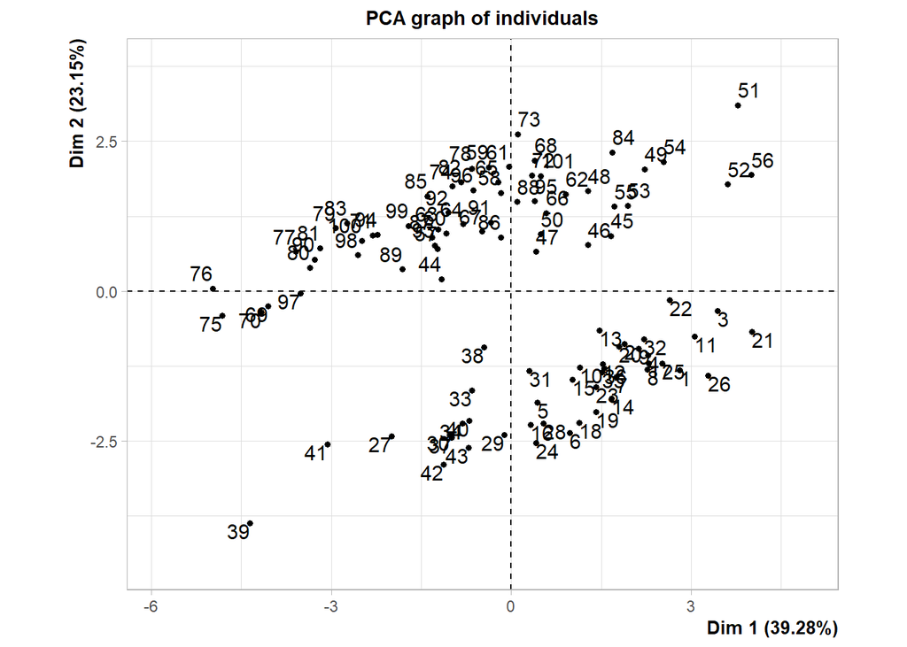

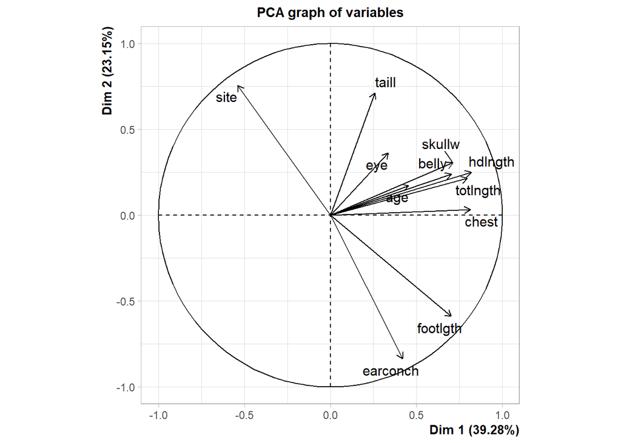

Первый график - проекции индивидов на плоскость первых 2 главных компонент

Второй график - исходные признаки с координатами ($f_{i1},f_{i2}$) равными корреляции между ними и главными компонентами

Векторы U

Первая главная компонента - общее значение (размер), признак site со знаком минус, т.к отрицательная корреляция с footlgth и earconch

Вторая главная компонента - разница между site+taill и footlgth+earconch

Третья главная компонента - разница между age+eye и totlngth+taill+footlgth

Четвертая главная компонента - разница между eye и age+chest+belly

```r
head(dataset3)
```

```
##   site age hdlngth skullw totlngth taill footlgth earconch  eye chest belly
## 1    1   8    94.1   60.4     89.0  36.0     74.5     54.5 15.2  28.0    36
## 2    1   6    92.5   57.6     91.5  36.5     72.5     51.2 16.0  28.5    33
## 3    1   6    94.0   60.0     95.5  39.0     75.4     51.9 15.5  30.0    34
## 4    1   6    93.2   57.1     92.0  38.0     76.1     52.2 15.2  28.0    34
## 5    1   2    91.5   56.3     85.5  36.0     71.0     53.2 15.1  28.5    33
## 6    1   1    93.1   54.8     90.5  35.5     73.2     53.6 14.2  30.0    32
```

```r
pca_result$svd$V
```

```
##             [,1]        [,2]        [,3]        [,4]        [,5]        [,6]
##  [1,] -0.2596884  0.47356683 -0.06817723 -0.13627603 -0.14426118  0.10086821
##  [2,]  0.2185762  0.10852170  0.54708980 -0.50111821  0.50410744  0.36007352
##  [3,]  0.3941743  0.15728623  0.02004416  0.09330264 -0.25546479  0.20772155
##  [4,]  0.3430210  0.19136584  0.08518639  0.02003919 -0.53006736  0.35374098
##  [5,]  0.3833618  0.13442186 -0.36440504  0.16450484  0.27726255  0.15184996
##  [6,]  0.1238553  0.44686119 -0.47167704  0.09186127  0.41981415  0.05615760
##  [7,]  0.3383987 -0.36909329 -0.16558882  0.12444058  0.07624258  0.05019062
##  [8,]  0.2015421 -0.52379782 -0.04484874  0.05365622  0.13759302  0.09614456
##  [9,]  0.1620536  0.22666346  0.54956353  0.70693998  0.13387879 -0.20225672
## [10,]  0.3918109  0.01973142 -0.02706778 -0.29066826 -0.28551176 -0.16755416
## [11,]  0.3384275  0.14994609  0.03052972 -0.28824550  0.03907718 -0.76481018
```

Собственные числа и вклад в общую дисперсию

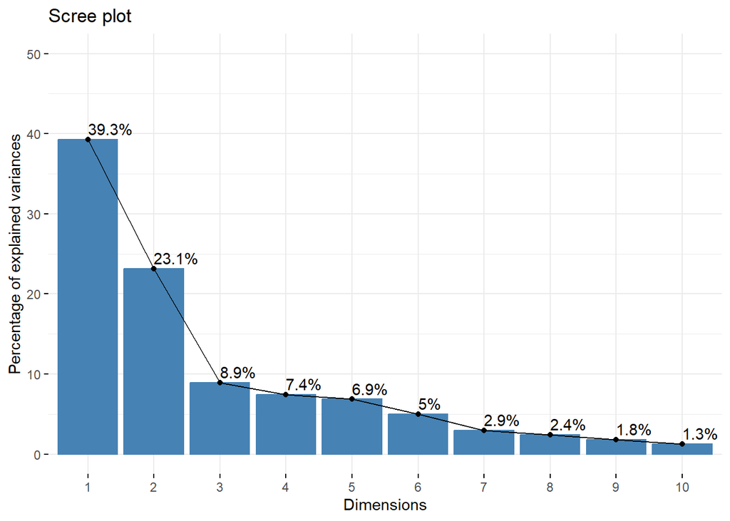

```r
fviz_eig(pca_result, addlabels = TRUE, ylim = c(0, 50))
```

```r
pca_result$eig
```

```
##         eigenvalue percentage of variance cumulative percentage of variance
## comp 1   4.3203156             39.2755964                          39.27560
## comp 2   2.5460762             23.1461476                          62.42174
## comp 3   0.9829467              8.9358794                          71.35762
## comp 4   0.8187550              7.4432273                          78.80085
## comp 5   0.7539182              6.8538016                          85.65465
## comp 6   0.5495019              4.9954719                          90.65012
## comp 7   0.3240601              2.9460009                          93.59613
## comp 8   0.2680977              2.4372520                          96.03338
## comp 9   0.1960747              1.7824976                          97.81587
## comp 10  0.1401994              1.2745403                          99.09042
## comp 11  0.1000543              0.9095849                         100.00000
```

Координаты признаков (матрица F)

```r
pca_result$var$coord
```

```
##               Dim.1      Dim.2       Dim.3       Dim.4       Dim.5       Dim.6
## site     -0.5397718  0.7556435 -0.06759341 -0.12330947 -0.12525976  0.07477199
## age       0.4543188  0.1731619  0.54240490 -0.45343722  0.43770874  0.26691673
## hdlngth   0.8193057  0.2509727  0.01987251  0.08442497 -0.22181615  0.15398065
## skullw    0.7129817  0.3053515  0.08445691  0.01813248 -0.46024933  0.26222251
## totlngth  0.7968317  0.2144893 -0.36128453  0.14885234  0.24074280  0.11256394
## taill     0.2574379  0.7130309 -0.46763793  0.08312075  0.36451817  0.04162873
## footlgth  0.7033742 -0.5889411 -0.16417084  0.11260016  0.06620026  0.03720550
## earconch  0.4189127 -0.8357943 -0.04446469  0.04855088  0.11946991  0.07127042
## eye       0.3368344  0.3616739  0.54485746  0.63967522  0.11624490 -0.14992967
## chest     0.8143934  0.0314843 -0.02683599 -0.26301142 -0.24790547 -0.12420521
## belly     0.7034341  0.2392604  0.03026829 -0.26081918  0.03393012 -0.56694151
```

$f_{ij}^2$

```r
pca_result$var$cos2
```

```
##               Dim.1        Dim.2        Dim.3        Dim.4       Dim.5
## site     0.29135362 0.5709971620 0.0045688693 0.0152052261 0.015690009
## age      0.20640554 0.0299850349 0.2942030786 0.2056053158 0.191588939
## hdlngth  0.67126186 0.0629872718 0.0003949168 0.0071275755 0.049202403
## skullw   0.50834291 0.0932395689 0.0071329697 0.0003287869 0.211829450
## totlngth 0.63494083 0.0460056561 0.1305265102 0.0221570182 0.057957097
## taill    0.06627426 0.5084130449 0.2186852294 0.0069090583 0.132873493
## footlgth 0.49473527 0.3468516043 0.0269520639 0.0126787957 0.004382475
## earconch 0.17548783 0.6985520580 0.0019771087 0.0023571877 0.014273058
## eye      0.11345740 0.1308080347 0.2968696477 0.4091843909 0.013512876
## chest    0.66323659 0.0009912612 0.0007201705 0.0691750050 0.061457121
## belly    0.49481950 0.0572455443 0.0009161693 0.0680266421 0.001151253
##                Dim.6
## site     0.005590850
## age      0.071244538
## hdlngth  0.023710041
## skullw   0.068760645
## totlngth 0.012670640
## taill    0.001732951
## footlgth 0.001384249
## earconch 0.005079473
## eye      0.022478905
## chest    0.015426934
## belly    0.321422681
```

$\frac{f_{ij}^2}{\lambda_j}\cdot{100}$, фактически векторы U с элементами, возведенными в квадрат и умноженными на 100

```r
pca_result$var$contrib
```

```
##              Dim.1       Dim.2       Dim.3       Dim.4      Dim.5      Dim.6
## site      6.743804 22.42655396  0.46481352  1.85711551  2.0811288  1.0174396
## age       4.777557  1.17769588 29.93072446 25.11194622 25.4124314 12.9652941
## hdlngth  15.537334  2.47389574  0.04017683  0.87053826  6.5262259  4.3148242
## skullw   11.766337  3.66208865  0.72567205  0.04015693 28.0971407 12.5132678
## totlngth 14.696631  1.80692374 13.27910310  2.70618416  7.6874519  2.3058410
## taill     1.534014 19.96849256 22.24792268  0.84384930 17.6243918  0.3153676
## footlgth 11.451369 13.62298578  2.74196587  1.54854574  0.5812932  0.2519098
## earconch  4.061921 27.43641556  0.20114098  0.28789903  1.8931840  0.9243776
## eye       2.626137  5.13763227 30.20200763 49.97641416  1.7923532  4.0907783
## chest    15.351577  0.03893289  0.07326648  8.44880396  8.1516965  2.8074396
## belly    11.453318  2.24838296  0.09320641  8.30854674  0.1527026 58.4934605
```

Координаты индивидов в новых признаках (матрица Z)

```r
pca_result$ind$coord[1:6,]
```

```
##       Dim.1      Dim.2      Dim.3       Dim.4      Dim.5      Dim.6
## 1 2.8151647 -1.3193822  1.2833919 -1.00061477  0.7261571  0.3506031
## 2 1.8833203 -0.8771158  0.7733753  0.26909475  0.9079401  0.2108604
## 3 3.4423274 -0.3348912 -0.4888287  0.03215024  0.9990092  0.5308825
## 4 2.2786386 -1.0729243 -0.1869038 -0.08108200  1.3771621  0.2346481
## 5 0.4308619 -1.8643095 -0.2079552  0.40613883 -0.4316850 -0.7824456
## 6 0.9757045 -2.3662369 -1.4317436  0.22856453 -0.6203938 -0.5165871
```

$\frac{z_{ij}^2}{||x_i||^2}$, $x_i$ - индивид

```r
pca_result$ind$cos2[1:6,]
```

```
##        Dim.1       Dim.2       Dim.3        Dim.4      Dim.5       Dim.6
## 1 0.56080842 0.123182256 0.116553545 7.085014e-02 0.03731368 0.008698379
## 2 0.54271589 0.117716674 0.091517623 1.107987e-02 0.12613585 0.006803216
## 3 0.81467357 0.007710574 0.016428303 7.106369e-05 0.06861487 0.019376532
## 4 0.59612034 0.132166434 0.004010693 7.548001e-04 0.21774750 0.006321457
## 5 0.03508952 0.656957459 0.008174118 3.117814e-02 0.03522371 0.115720277
## 6 0.08600490 0.505828181 0.185189802 4.719590e-03 0.03477134 0.024108696
```

Индивиды и проекции ортов в плоскости первых 2 главных компонент

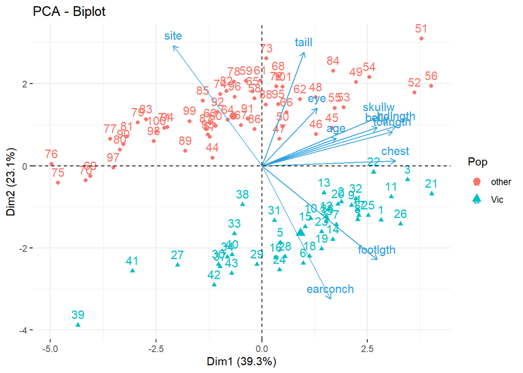

```r
fviz_pca_biplot(pca_result, repel = FALSE,
                col.var = "#2E9FDF",
                col.ind = as.factor(dataset1$Pop),
                legend.title="Pop"
                )
```

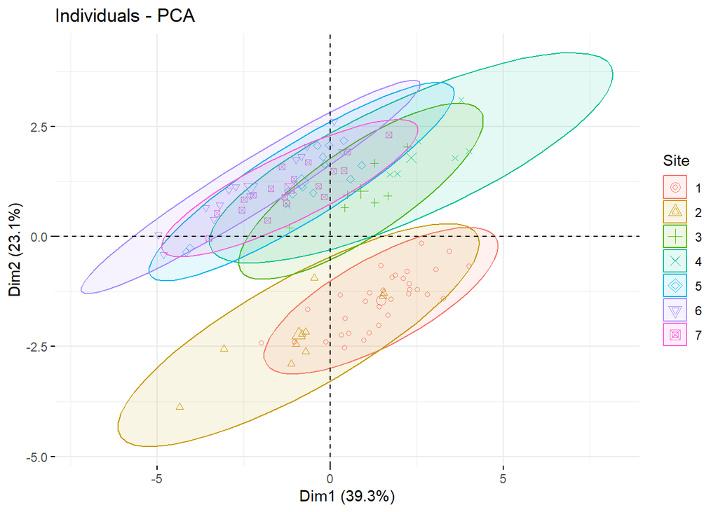

```r
fviz_pca_ind(pca_result,
             geom.ind = "point",
             col.ind = as.factor(dataset1$site),
             addEllipses = TRUE,
             legend.title = "Site"
             )
```

```r
dataset3[51,]
```

```
##    site age hdlngth skullw totlngth taill footlgth earconch  eye chest belly
## 51    4   7    96.9     63     91.5    43     71.3       46 17.5    30  36.5
```

Выброс, индивид 39: маленький опоссум с большими ушами и лапами

```r
dataset3[39,]
```

```
##    site age hdlngth skullw totlngth taill footlgth earconch eye chest belly
## 39    2   1    84.7   51.5       75    34     68.7     53.4  13    25    25
```

Удаляем выбросы

```r
dataset4 <- dataset3[-c(39,51),]
pca_result2 <- PCA(dataset4, ncp=6)
```

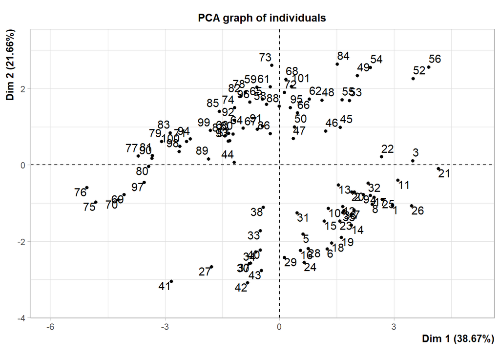

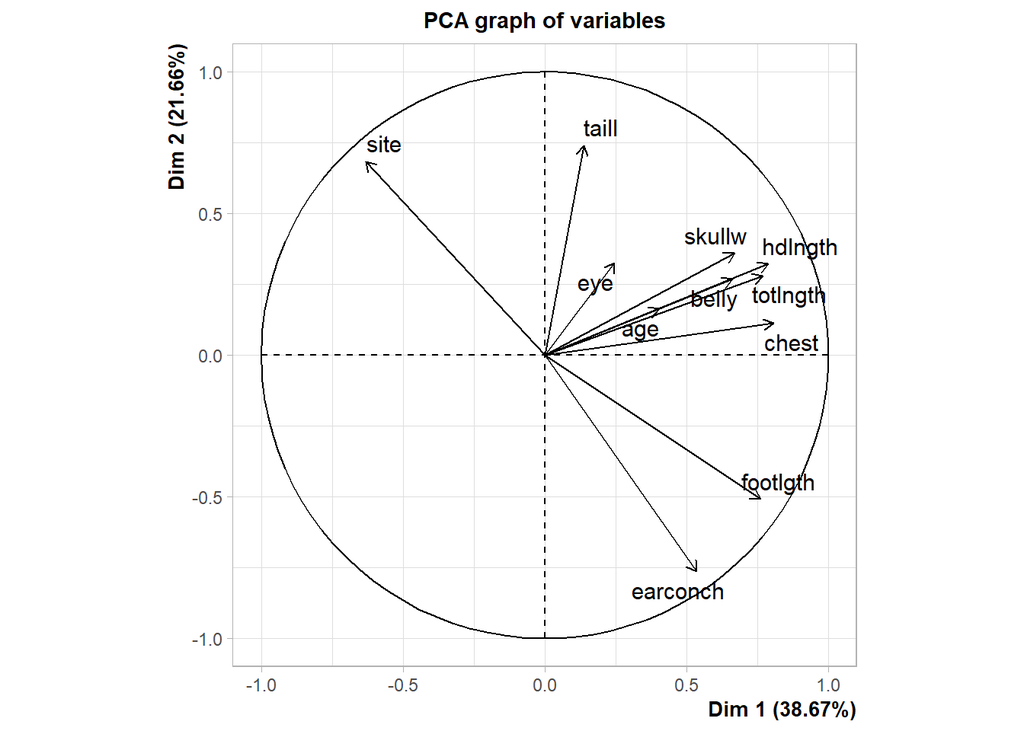

Biplot без выбросов

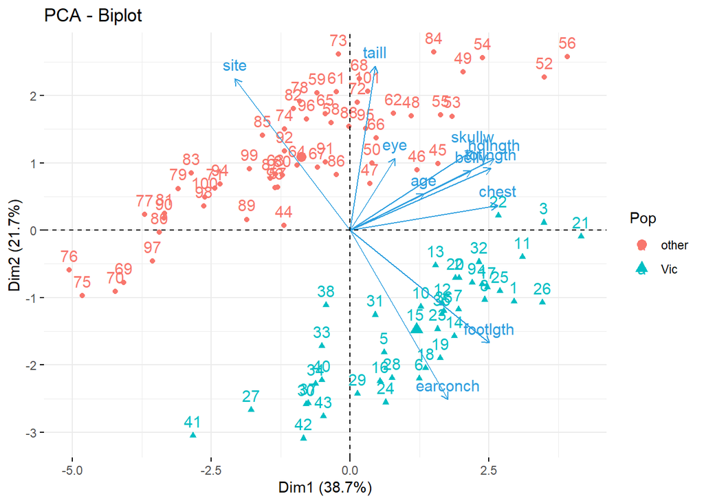

```r
fviz_pca_biplot(pca_result2, repel = FALSE,
                col.var = "#2E9FDF",
                col.ind = as.factor(dataset1[-c(39,51),]$Pop),
                legend.title="Pop"
                )
```

```r
dataset5 <- dataset1 %>% select(-c(sex,site))
head(dataset5)
```

```
##   Pop age hdlngth skullw totlngth taill footlgth earconch  eye chest belly
## 1 Vic   8    94.1   60.4     89.0  36.0     74.5     54.5 15.2  28.0    36
## 2 Vic   6    92.5   57.6     91.5  36.5     72.5     51.2 16.0  28.5    33
## 3 Vic   6    94.0   60.0     95.5  39.0     75.4     51.9 15.5  30.0    34
## 4 Vic   6    93.2   57.1     92.0  38.0     76.1     52.2 15.2  28.0    34
## 5 Vic   2    91.5   56.3     85.5  36.0     71.0     53.2 15.1  28.5    33
## 6 Vic   1    93.1   54.8     90.5  35.5     73.2     53.6 14.2  30.0    32
```

```r
dataset5[,1] <- as.factor(dataset5[,1])
```

```r
library("caTools")
set.seed(13)
sample <- sample.split(dataset5, SplitRatio = 0.75)
train <- subset(dataset5, sample == TRUE)
test <- subset(dataset5, sample == FALSE)
```

```r
train.manova <- manova(cbind(age,hdlngth,skullw,totlngth,taill,footlgth,earconch,eye,chest,belly) ~ Pop, data = train)

summary(train.manova, 'Wilks')
```

```
##           Df    Wilks approx F num Df den Df    Pr(>F)
## Pop        1 0.063594   92.765     10     63 < 2.2e-16 ***
## Residuals 72
## ---
## Signif. codes:  0 '***' 0.001 '**' 0.01 '*' 0.05 '.' 0.1 ' ' 1
```

```r
summary(train.manova, 'Roy')
```

```
##           Df    Roy approx F num Df den Df    Pr(>F)
## Pop        1 14.725   92.765     10     63 < 2.2e-16 ***
## Residuals 72
## ---
## Signif. codes:  0 '***' 0.001 '**' 0.01 '*' 0.05 '.' 0.1 ' ' 1
```

```r
library("MASS")
full.lda <- lda(dataset5[,2:11], dataset5[,1]) #LDA
full.ldap <- predict(full.lda, dataset5[,2:11]) #предсказываем
#таблица ошибок классификации
full.ldapc <- full.ldap$class
ct <- table(full.ldapc, dataset5[,1])
ct
```

```
##
## full.ldapc other Vic
##      other    58   0
##      Vic       0  43
```

```r
diag(prop.table(ct, 2)) #Столбцы - настоящие классы, строки - предсказанные классы.
```

```
## other   Vic
##     1     1
```

```r
#таблица ошибок классификации по train data на train и test
train.lda <- lda(train[,2:11], train[,1])
train.ldap <- predict(train.lda, test[,2:11])
train.ldapc <- train.ldap$class
ct <- table(train.ldapc, test[,1])
ct
```

```
##
## train.ldapc other Vic
##       other    15   0
##       Vic       0  12
```

```r
diag(prop.table(ct, 2))
```

```
## other   Vic
##     1     1
```

```r
train.ldap <- predict(train.lda, train[,2:11])
train.ldapc <- train.ldap$class
ct <- table(train.ldapc, train[,1])
ct
```

```
##
## train.ldapc other Vic
##       other    43   0
##       Vic       0  31
```

```r
diag(prop.table(ct, 2))
```

```
## other   Vic
##     1     1
```

```r
train.lda
```

```
## Call:
## lda(train[, 2:11], train[, 1])
##
## Prior probabilities of groups:
##     other       Vic
## 0.5810811 0.4189189
##
## Group means:
##            age  hdlngth   skullw totlngth    taill footlgth earconch      eye
## other 3.720930 92.36512 57.08372 86.77907 37.95349 65.37209 44.87907 15.18372
## Vic   3.967742 93.25806 57.31290 88.59677 36.24194 73.11290 52.72903 14.93226
##          chest    belly
## other 26.69767 32.76744
## Vic   27.85484 33.03226
##
## Coefficients of linear discriminants:
##                  LD1
## age       0.12863933
## hdlngth  -0.18824101
## skullw   -0.09589453
## totlngth  0.16007261
## taill    -0.47147424
## footlgth  0.31700474
## earconch  0.52835239
## eye       0.06591553
## chest     0.15201564
## belly    -0.10833186
```

```r
#Кросс-валидация
cv.lda <- lda(dataset5[,2:11], dataset5[,1], CV = T)
cv.ldac <- cv.lda$class
ct <- table(cv.ldac, dataset5[,1])
ct
```

```
##
## cv.ldac other Vic
##   other    58   0
##   Vic       0  43
```

```r
diag(prop.table(ct, 2))
```

```
## other   Vic
##     1     1
```

```r
#QDA
full.qda <- qda(dataset5[,2:11], dataset5[,1])
full.qdap <- predict(full.qda, dataset5[,2:11])
full.qdapc <- full.qdap$class
ct <- table(full.qdapc, dataset5[,1])
ct
```

```
##
## full.qdapc other Vic
##      other    58   0
##      Vic       0  43
```

```r
diag(prop.table(ct, 2))
```

```
## other   Vic
##     1     1
```

```r
train.qda <- qda(train[,2:11], train[,1])
test.qdap <- predict(train.qda, test[,2:11])
test.qdapc <- test.qdap$class
ct <- table(test.qdapc, test[,1])
ct
```

```
##
## test.qdapc other Vic
##      other    15   0
##      Vic       0  12
```

```r
diag(prop.table(ct, 2))
```

```
## other   Vic
##     1     1
```

```r
train.qdap <- predict(train.qda, train[,2:11])
train.qdapc <- train.qdap$class
ct <- table(train.qdapc, train[,1])
ct
```

```
##
## train.qdapc other Vic
##       other    43   0
##       Vic       0  31
```

```r
diag(prop.table(ct, 2))
```

```
## other   Vic
##     1     1
```

```r
train.qda
```

```
## Call:
## qda(train[, 2:11], train[, 1])
##
## Prior probabilities of groups:
##     other       Vic
## 0.5810811 0.4189189
##
## Group means:
##            age  hdlngth   skullw totlngth    taill footlgth earconch      eye
## other 3.720930 92.36512 57.08372 86.77907 37.95349 65.37209 44.87907 15.18372
## Vic   3.967742 93.25806 57.31290 88.59677 36.24194 73.11290 52.72903 14.93226
##          chest    belly
## other 26.69767 32.76744
## Vic   27.85484 33.03226
```